# Ensemble_Travel_Package_Purchase_Prediction_Ong_Min_Hau

```python
# Library to suppress warnings or deprecation notes
import warnings
warnings.filterwarnings('ignore')

# Libraries to help with reading and manipulating data
import numpy as np
import pandas as pd

# Libraries to help with data visualization
import matplotlib.pyplot as plt
%matplotlib inline
import seaborn as sns

# Libraries to split data, impute missing values
from sklearn.model_selection import train_test_split
from sklearn.impute import SimpleImputer

# Libraries to import decision tree classifier and different ensemble classifiers
from sklearn.ensemble import BaggingClassifier
from sklearn.ensemble import RandomForestClassifier
from sklearn.ensemble import AdaBoostClassifier, GradientBoostingClassifier
from xgboost import XGBClassifier
from sklearn.ensemble import StackingClassifier
from sklearn.tree import DecisionTreeClassifier

# Libtune to tune model, get different metric scores
from sklearn import metrics
from sklearn.metrics import confusion_matrix, classification_report, accuracy_score, precision_score, recall_score
from sklearn.model_selection import GridSearchCV
```

```python
#Loading dataset
tourism = pd.read_excel('Tourism.xlsx', 'Tourism')
```

```python
# copying data to another varaible to avoid any changes to original data
data=tourism.copy()


# View the first 5 rows of the dataset
data.head()
```

|  | CustomerID | ProdTaken | Age | TypeofContact | CityTier | DurationOfPitch | Occupation | Gender | NumberOfPersonVisiting | NumberOfFollowups | ProductPitched | PreferredPropertyStar | MaritalStatus | NumberOfTrips | Passport | PitchSatisfactionScore | OwnCar | NumberOfChildrenVisiting | Designation | MonthlyIncome |
| --- | --- | --- | --- | --- | --- | --- | --- | --- | --- | --- | --- | --- | --- | --- | --- | --- | --- | --- | --- | --- |
| 0 | 200000 | 1 | 41.0 | Self Enquiry | 3 | 6.0 | Salaried | Female | 3 | 3.0 | Deluxe | 3.0 | Single | 1.0 | 1 | 2 | 1 | 0.0 | Manager | 20993.0 |
| 1 | 200001 | 0 | 49.0 | Company Invited | 1 | 14.0 | Salaried | Male | 3 | 4.0 | Deluxe | 4.0 | Divorced | 2.0 | 0 | 3 | 1 | 2.0 | Manager | 20130.0 |
| 2 | 200002 | 1 | 37.0 | Self Enquiry | 1 | 8.0 | Free Lancer | Male | 3 | 4.0 | Basic | 3.0 | Single | 7.0 | 1 | 3 | 0 | 0.0 | Executive | 17090.0 |
| 3 | 200003 | 0 | 33.0 | Company Invited | 1 | 9.0 | Salaried | Female | 2 | 3.0 | Basic | 3.0 | Divorced | 2.0 | 1 | 5 | 1 | 1.0 | Executive | 17909.0 |
| 4 | 200004 | 0 | NaN | Self Enquiry | 1 | 8.0 | Small Business | Male | 2 | 3.0 | Basic | 4.0 | Divorced | 1.0 | 0 | 5 | 1 | 0.0 | Executive | 18468.0 |

```python
# View the first last 5 rows of the dataset
data.tail()
```

|  | CustomerID | ProdTaken | Age | TypeofContact | CityTier | DurationOfPitch | Occupation | Gender | NumberOfPersonVisiting | NumberOfFollowups | ProductPitched | PreferredPropertyStar | MaritalStatus | NumberOfTrips | Passport | PitchSatisfactionScore | OwnCar | NumberOfChildrenVisiting | Designation | MonthlyIncome |
| --- | --- | --- | --- | --- | --- | --- | --- | --- | --- | --- | --- | --- | --- | --- | --- | --- | --- | --- | --- | --- |
| 4883 | 204883 | 1 | 49.0 | Self Enquiry | 3 | 9.0 | Small Business | Male | 3 | 5.0 | Deluxe | 4.0 | Unmarried | 2.0 | 1 | 1 | 1 | 1.0 | Manager | 26576.0 |
| 4884 | 204884 | 1 | 28.0 | Company Invited | 1 | 31.0 | Salaried | Male | 4 | 5.0 | Basic | 3.0 | Single | 3.0 | 1 | 3 | 1 | 2.0 | Executive | 21212.0 |
| 4885 | 204885 | 1 | 52.0 | Self Enquiry | 3 | 17.0 | Salaried | Female | 4 | 4.0 | Standard | 4.0 | Married | 7.0 | 0 | 1 | 1 | 3.0 | Senior Manager | 31820.0 |
| 4886 | 204886 | 1 | 19.0 | Self Enquiry | 3 | 16.0 | Small Business | Male | 3 | 4.0 | Basic | 3.0 | Single | 3.0 | 0 | 5 | 0 | 2.0 | Executive | 20289.0 |
| 4887 | 204887 | 1 | 36.0 | Self Enquiry | 1 | 14.0 | Salaried | Male | 4 | 4.0 | Basic | 4.0 | Unmarried | 3.0 | 1 | 3 | 1 | 2.0 | Executive | 24041.0 |

```python
# Understand the shape of the dataset
data.shape
```

```
(4888, 20)
```

#### Check the data types of the columns for the dataset:

```python
data.info()
```

```
<class 'pandas.core.frame.DataFrame'>
RangeIndex: 4888 entries, 0 to 4887
Data columns (total 20 columns):
 #   Column                    Non-Null Count  Dtype
---  ------                    --------------  -----
 0   CustomerID                4888 non-null   int64
 1   ProdTaken                 4888 non-null   int64
 2   Age                       4662 non-null   float64
 3   TypeofContact             4863 non-null   object
 4   CityTier                  4888 non-null   int64
 5   DurationOfPitch           4637 non-null   float64
 6   Occupation                4888 non-null   object
 7   Gender                    4888 non-null   object
 8   NumberOfPersonVisiting    4888 non-null   int64
 9   NumberOfFollowups         4843 non-null   float64
 10  ProductPitched            4888 non-null   object
 11  PreferredPropertyStar     4862 non-null   float64
 12  MaritalStatus             4888 non-null   object
 13  NumberOfTrips             4748 non-null   float64
 14  Passport                  4888 non-null   int64
 15  PitchSatisfactionScore    4888 non-null   int64
 16  OwnCar                    4888 non-null   int64
 17  NumberOfChildrenVisiting  4822 non-null   float64
 18  Designation               4888 non-null   object
 19  MonthlyIncome             4655 non-null   float64
dtypes: float64(7), int64(7), object(6)
memory usage: 763.9+ KB
```

- Sighted some columns have missing values, we will treat it after performing EDA so that our EDA could be purely based on original values from dataset.

# 1) Feature Engineering

As stated in the problem description that the category of **CityTier** are ordered in the following sequence:  
Tier 1 > Tier 2 > Tier 3

However, the sequence of numerical representation is currently in this order: 1 < 2 < 3. We shall convert the numerical representation to its corresponding Tier level and then apply OrdinalEncoder to set its order accordingly.

```python
# verifying the unique values of CityTier column
data['CityTier'].unique()
```

```
array([3, 1, 2])
```

```python
# mapping respective values of CityTier with its corresponding Tier level

df_CityTier = data[['CityTier']]
df_CityTier['DuplicatedCityTier'] = df_CityTier['CityTier'].copy()
df_CityTier['DuplicatedCityTier'].replace({
    1: 'Tier 1',
    2: 'Tier 2',
    3: 'Tier 3',
}, inplace=True)

df_CityTier.head()
```

|  | CityTier | DuplicatedCityTier |
| --- | --- | --- |
| 0 | 3 | Tier 3 |
| 1 | 1 | Tier 1 |
| 2 | 1 | Tier 1 |
| 3 | 1 | Tier 1 |
| 4 | 1 | Tier 1 |

```python
# now let's replace respective values of CityTier with its corresponding Tier level
data['CityTier'] = df_CityTier['DuplicatedCityTier']
data['CityTier'].head()
```

```
0    Tier 3
1    Tier 1
2    Tier 1
3    Tier 1
4    Tier 1
Name: CityTier, dtype: object
```

```python
# The categories are ordered i.e. Tier 1 > Tier 2 > Tier 3
data['CityTier'] = pd.Categorical(data['CityTier'], ordered=True, categories=['Tier 3', 'Tier 2', 'Tier 1'])

# Verifying the order by checking Tier 3 is the minimum
data['CityTier'].min()
```

```
'Tier 3'
```

# 2) Basic Summary Statistics

**To analyse categorical features easier, we temporarily convert the data type of column 'ProdTaken','Passport' and 'OwnCar' into categorical together with object-type variables first. Before model building we will convert it back to int64.**

```python
# Now we group those categorical integer-type variables into a list
cat_cols1 = ['ProdTaken','Passport','OwnCar']
```

```python
# And also group those object-type variables into a list
cat_cols2 = list(data.dtypes[data.dtypes.values == 'object'].index)
```

```python
cat_cols = cat_cols1 + cat_cols2
cat_cols
```

```
['ProdTaken',
 'Passport',
 'OwnCar',
 'TypeofContact',
 'Occupation',
 'Gender',
 'ProductPitched',
 'MaritalStatus',
 'Designation']
```

```python
# Converting the data type of categorical features to 'category'
data[cat_cols] = data[cat_cols].astype('category')
```

#### Summary of the dataset:

```python
data.describe().T
```

|  | count | mean | std | min | 25% | 50% | 75% | max |
| --- | --- | --- | --- | --- | --- | --- | --- | --- |
| CustomerID | 4888.0 | 202443.500000 | 1411.188388 | 200000.0 | 201221.75 | 202443.5 | 203665.25 | 204887.0 |
| Age | 4662.0 | 37.622265 | 9.316387 | 18.0 | 31.00 | 36.0 | 44.00 | 61.0 |
| DurationOfPitch | 4637.0 | 15.490835 | 8.519643 | 5.0 | 9.00 | 13.0 | 20.00 | 127.0 |
| NumberOfPersonVisiting | 4888.0 | 2.905074 | 0.724891 | 1.0 | 2.00 | 3.0 | 3.00 | 5.0 |
| NumberOfFollowups | 4843.0 | 3.708445 | 1.002509 | 1.0 | 3.00 | 4.0 | 4.00 | 6.0 |
| PreferredPropertyStar | 4862.0 | 3.581037 | 0.798009 | 3.0 | 3.00 | 3.0 | 4.00 | 5.0 |
| NumberOfTrips | 4748.0 | 3.236521 | 1.849019 | 1.0 | 2.00 | 3.0 | 4.00 | 22.0 |
| PitchSatisfactionScore | 4888.0 | 3.078151 | 1.365792 | 1.0 | 2.00 | 3.0 | 4.00 | 5.0 |
| NumberOfChildrenVisiting | 4822.0 | 1.187267 | 0.857861 | 0.0 | 1.00 | 1.0 | 2.00 | 3.0 |
| MonthlyIncome | 4655.0 | 23619.853491 | 5380.698361 | 1000.0 | 20346.00 | 22347.0 | 25571.00 | 98678.0 |

- The mean and median of customer age are approximate to each other, which are 37.6 years old and 36 years old respectively;
- The maximum DurationOfPitch is 127, which is likely an outlier because its 3rd quartile value is only 20;
- The maximum NumberOfTrips, 22 times, is also likely an outlier because its 3rd quartile value is only 4;
- The distribution of MonthlyIncome is right-skewed, because its mean value is significantly larger than its median.

```python
data.describe(include='category').T
```

|  | count | unique | top | freq |
| --- | --- | --- | --- | --- |
| ProdTaken | 4888 | 2 | 0 | 3968 |
| TypeofContact | 4863 | 2 | Self Enquiry | 3444 |
| CityTier | 4888 | 3 | Tier 1 | 3190 |
| Occupation | 4888 | 4 | Salaried | 2368 |
| Gender | 4888 | 3 | Male | 2916 |
| ProductPitched | 4888 | 5 | Basic | 1842 |
| MaritalStatus | 4888 | 4 | Married | 2340 |
| Passport | 4888 | 2 | 0 | 3466 |
| OwnCar | 4888 | 2 | 1 | 3032 |
| Designation | 4888 | 5 | Executive | 1842 |

```python
data.ProdTaken.value_counts(1)
```

```
0    0.811784
1    0.188216
Name: ProdTaken, dtype: float64
```

- The dataset is imbalance because 81.2% of it are customers who didn't purchase a travel package, compared with only 18.8% who did purchase a package.
- Among the categorical variables, only TypeofContact has missing values.
- Majority of customers were contacted via self-enquiry.
- Most customers are from Tier-1 city.
- Sighted 3 types of gender, we need to look further into this category to understand this column.
- Most of the customers contacted by salespersons didn't have a passport.
- In constrast, most customers own a car.

```python
# update cat_cols list
cat_cols.extend(['CityTier'])
cat_cols
```

```
['ProdTaken',
 'Passport',
 'OwnCar',
 'TypeofContact',
 'Occupation',
 'Gender',
 'ProductPitched',
 'MaritalStatus',
 'Designation',
 'CityTier']
```

```python
# Printing number of count of each unique value in every categorical column
for column in cat_cols:
    print(data[column].value_counts(dropna=False))
    print("-" * 50)
```

```
0    3968
1     920
Name: ProdTaken, dtype: int64
--------------------------------------------------
0    3466
1    1422
Name: Passport, dtype: int64
--------------------------------------------------
1    3032
0    1856
Name: OwnCar, dtype: int64
--------------------------------------------------
Self Enquiry       3444
Company Invited    1419
NaN                  25
Name: TypeofContact, dtype: int64
--------------------------------------------------
Salaried          2368
Small Business    2084
Large Business     434
Free Lancer          2
Name: Occupation, dtype: int64
--------------------------------------------------
Male       2916
Female     1817
Fe Male     155
Name: Gender, dtype: int64
--------------------------------------------------
Basic           1842
Deluxe          1732
Standard         742
Super Deluxe     342
King             230
Name: ProductPitched, dtype: int64
--------------------------------------------------
Married      2340
Divorced      950
Single        916
Unmarried     682
Name: MaritalStatus, dtype: int64
--------------------------------------------------
Executive         1842
Manager           1732
Senior Manager     742
AVP                342
VP                 230
Name: Designation, dtype: int64
--------------------------------------------------
Tier 1    3190
Tier 3    1500
Tier 2     198
Name: CityTier, dtype: int64
--------------------------------------------------
```

- Notice that the gender variable has "Female" and "Fe Male" values, we shall correct the value of "Fe Male" by changing it to "Female";
- From ProductPitched we could deduce that the products are being ranked in this order: Basic < Standard < Deluxe < Super Deluxe < King. From the comparison above we can see that salespersons pitched Basic product the most, followed by Deluxe;
- While by convention we know that Senior Manager is at a higher rank than Manager but, in some organisation, Executive could rank higher or lower than a Manager/Seior Manager. Hence, it would be advisable that for now, we shall continue studying this case without ranking one designation higher than another until we derive some insightful evidence about its ranking. Anyway, we could see that most customers are executive level.
- The largest group of customers are from Tier-1 city, while the second largest group is from Tier-3 city instead of Tier-2.

```python
# replacing value 'Fe Male' with 'Female'
data['Gender'].replace({'Fe Male':'Female'}, inplace=True)

# Converting the data type of Gender back to categorical
data['Gender'] = data['Gender'].astype('category')

data['Gender'].value_counts()
```

```
Male      2916
Female    1972
Name: Gender, dtype: int64
```

```python
# Set the order of ProductPitched
data['ProductPitched'] = pd.Categorical(data['ProductPitched'], ordered=True,
                                        categories=['Basic', 'Standard', 'Deluxe', 'Super Deluxe', 'King'])

# Verifying the order by checking King is the highest rank
data['ProductPitched'].max()
```

```
'King'
```

Noted also that CustomerID is unique for every customer, thus it won't be useful for our analysis.

```python
# drop CustomerID column
data.drop('CustomerID', axis=1, inplace=True)
```

# 3) EDA

## 3.1) Univariate Analysis

```python
# While doing univariate analysis of numerical variables we want to study their central tendency and dispersion.
# Let us write a function that will help us create boxplot and histogram for any input numerical variable.
# This function takes the numerical column as the input and returns the boxplots and histograms for the variable.
# Let us see if this help us write faster and cleaner code.
def histogram_boxplot(feature, figsize=(15,10), bins = None):
    """ Boxplot and histogram combined
    feature: 1-d feature array
    figsize: size of fig (default (9,8))
    bins: number of bins (default None / auto)
    """
    sns.set(font_scale=2) # setting the font scale of the seaborn
    f2, (ax_box2, ax_hist2) = plt.subplots(nrows = 2, # Number of rows of the subplot grid= 2
                                           sharex = True, # x-axis will be shared among all subplots
                                           gridspec_kw = {"height_ratios": (.25, .75)},
                                           figsize = figsize
                                           ) # creating the 2 subplots
    sns.boxplot(x=feature, ax=ax_box2, showmeans=True, color='violet') # boxplot will be created and a star will indicate the mean value of the column
    sns.histplot(x=feature, kde=F, ax=ax_hist2, bins=bins,palette="winter") if bins else sns.histplot(x=feature, kde=False, ax=ax_hist2) # For histogram
    ax_hist2.axvline(np.mean(feature), color='green', linestyle='--') # Add mean to the histogram
    ax_hist2.axvline(np.median(feature), color='black', linestyle='-') # Add median to the histogram
```

Let's try explore every feature:

#### Observations on Age:

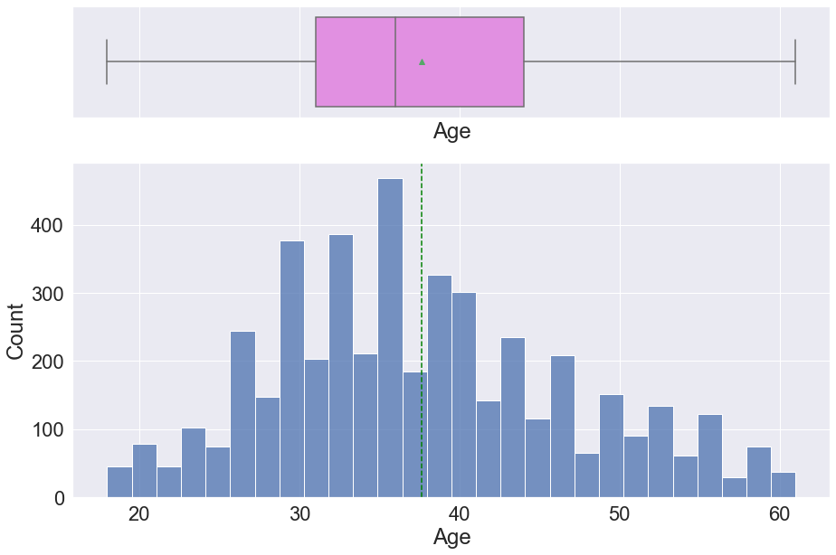

```python
histogram_boxplot(data['Age'])
```

- Distribution of Age is slightly skewed to the right.
- Most customers are between 30 to 45 years old, with mean age at 37.6 years old.
- There is no outlier in this column.

#### Observations on DurationOfPitch:

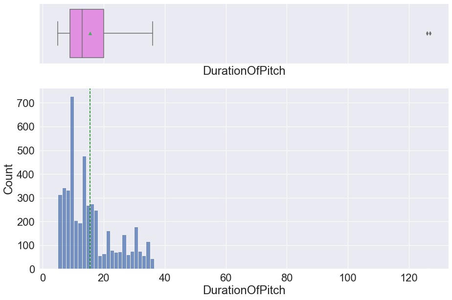

```python
histogram_boxplot(data['DurationOfPitch'])
```

- The distribution of DurationOfPitch is right-skewed.
- There are a couple of extreme outliers at the right end.
- Majority of DurationOfPitch is lesser than 20.

#### Observations on NumberOfTrips:

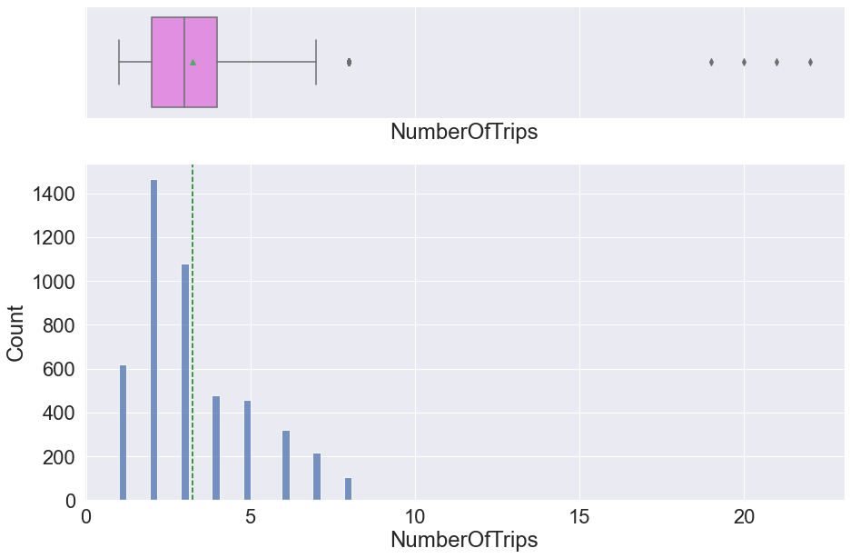

```python
histogram_boxplot(data['NumberOfTrips'])
```

#### Observations on MonthlyIncome:

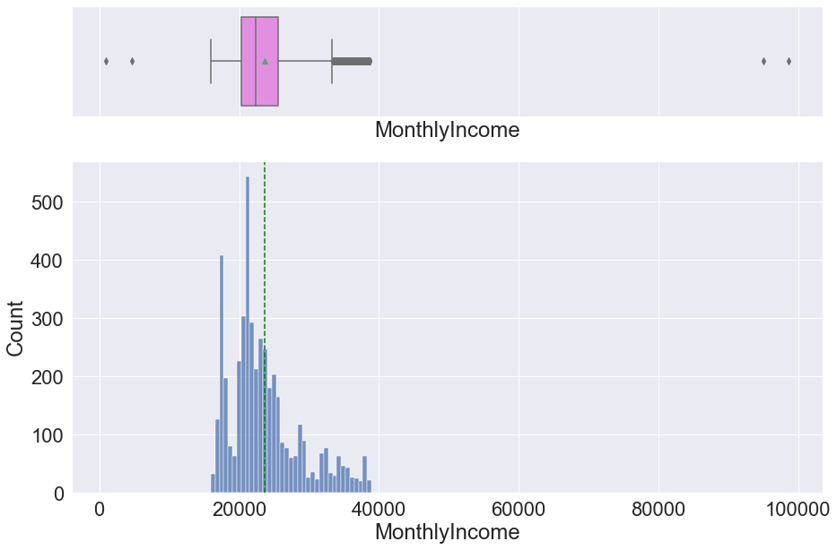

```python
histogram_boxplot(data['MonthlyIncome'])
```

```python
# Function to create barplots that indicate percentage for each category.

def perc_on_bar(feature):
    '''
    plot
    feature: categorical feature
    the function won't work if a column is passed in hue parameter
    '''
    total = len(feature) # length of the column
    ax = sns.countplot(feature,palette='winter')
    for p in ax.patches:
        percentage = '{:.1f}%'.format(100 * p.get_height()/total) # percentage of each class of the category
        x = p.get_x() + p.get_width() / 2 - 0.15 # width of the plot
        y = p.get_y() + p.get_height()           # hieght of the plot
        ax.annotate(percentage, (x, y), size = 12) # annotate the percantage
    plt.show() # show the plot
```

#### Observations on whether the customer has purchased a package or not:

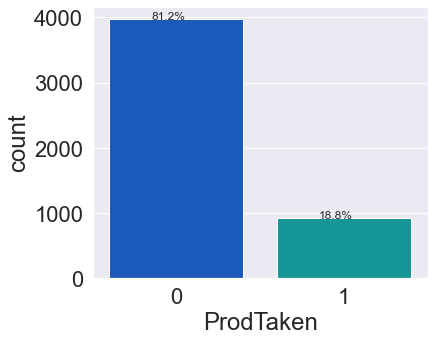

```python
plt.figure(figsize=(6, 5))
perc_on_bar(data["ProdTaken"])
```

- 18.8% of customers purchased a travel package.

#### Observations on TypeofContact:

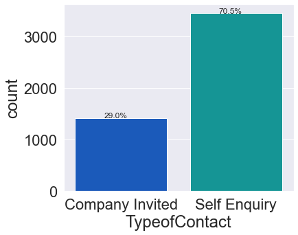

```python
plt.figure(figsize=(6, 5))
perc_on_bar(data["TypeofContact"])
```

- 70.5% of customers were contacted through self-enquiry.

#### Observations on CityTier:

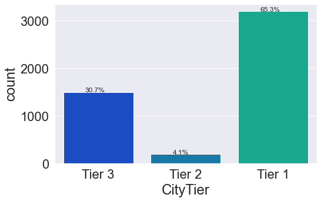

```python
plt.figure(figsize=(8, 5))
perc_on_bar(data["CityTier"])
```

- 65.3% of customers contacted are from Tier-1 city
- Only 4.1% of customers are from Tier-2 city

#### Observations on Occupation:

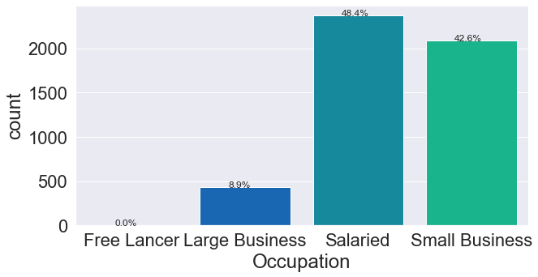

```python
plt.figure(figsize=(10, 5))
perc_on_bar(data["Occupation"])
```

- Most customers are either salaried employees or small business owners.
- The percentage of freeelancer is close to zero because there are only 2 records of entire datasets constitute this category. We can combine the records of freelancer with small business beccause freelancer could also be interpreted as small business with only 1 employee who is also the business owner themselves.

```python
# combine freelancer records with small business
data['Occupation'].replace({'Free Lancer': 'Small Business'}, inplace=True)

# Converting the data type of Occupation back to categorical
data['Occupation'] = data['Occupation'].astype('category')

data['Occupation'].value_counts()
```

```
Salaried          2368
Small Business    2086
Large Business     434
Name: Occupation, dtype: int64
```

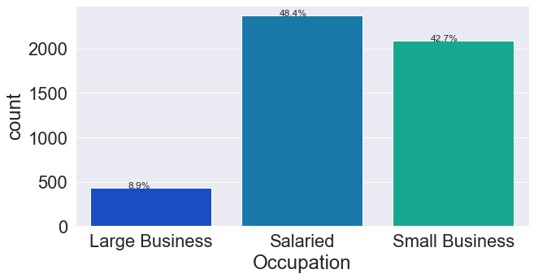

```python
# review observations on Occupation
plt.figure(figsize=(10, 5))
perc_on_bar(data["Occupation"])
```

- We have reduced the number of categories of Occupation to three categories.

#### Observations on Gender:

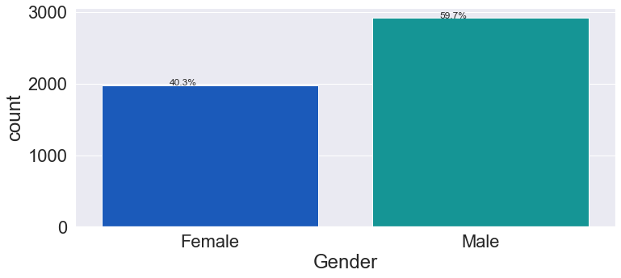

```python
plt.figure(figsize=(12, 5))
perc_on_bar(data["Gender"])
```

- nearly 60% of customers are male.

#### Observations on ProductPitched:

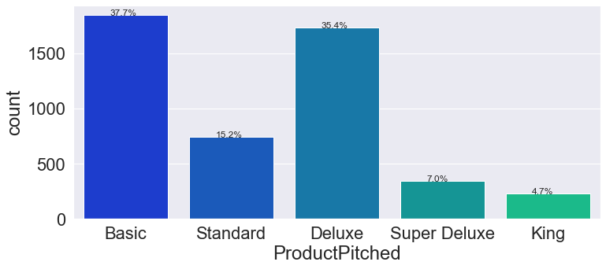

```python
plt.figure(figsize=(12, 5))
perc_on_bar(data["ProductPitched"])
```

- Basic and Deluxe are the two most-pitched packages by salespersons.
- To be specific, 73% of customers were pitched for either Basic or Deluxe package.

#### Observations on MaritalStatus:

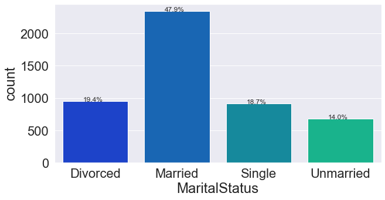

```python
plt.figure(figsize=(10, 5))
perc_on_bar(data["MaritalStatus"])
```

- nearly half of the obseravations from our dataset are married.

#### Observations on Passport:

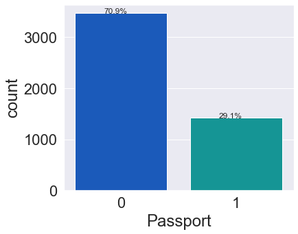

```python
plt.figure(figsize=(6, 5))
perc_on_bar(data["Passport"])
```

- Approx 29.1% of customers have a passport.

#### Observations on OwnCar:

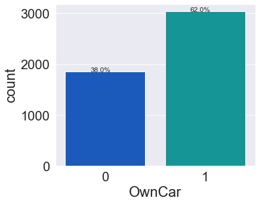

```python
plt.figure(figsize=(6, 5))
perc_on_bar(data["OwnCar"])
```

- Approx 62% of customers own a car.

#### Observations on Designation:

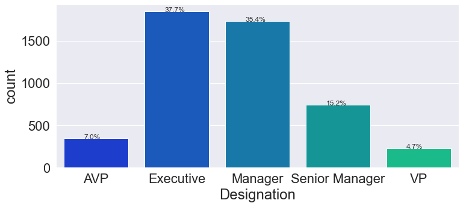

```python
plt.figure(figsize=(12, 5))
perc_on_bar(data["Designation"])
```

- Executives form the largest group of customers, followed by Manager, and then Senior Manager.

#### Observations on NumberOfPersonVisiting:

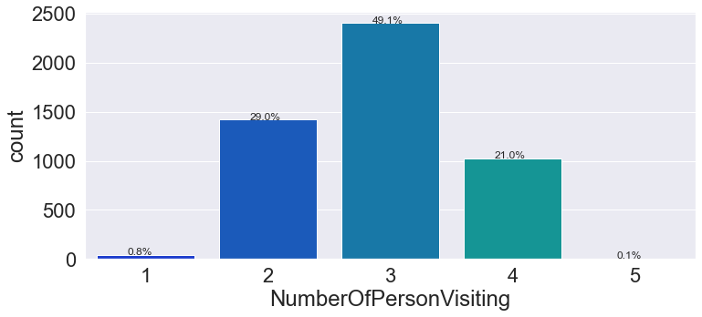

```python
plt.figure(figsize=(12, 5))
perc_on_bar(data["NumberOfPersonVisiting"])
```

- Normally for every customer, there are 2 to 4 persons planning to take the trip with them.

#### Observations on NumberOfFollowups:

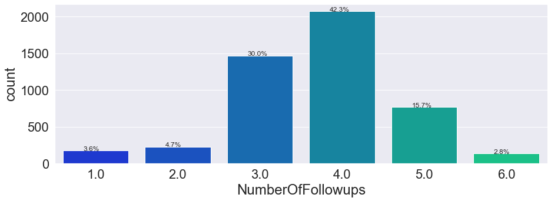

```python
plt.figure(figsize=(15, 5))
perc_on_bar(data["NumberOfFollowups"])
```

- Salespersons normally do 3 to 5 times of follow-ups for every customer.

#### Observations on PreferredPropertyStar:

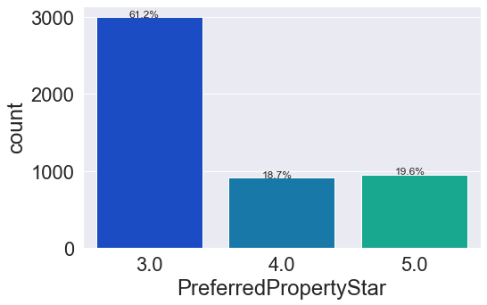

```python
plt.figure(figsize=(8, 5))
perc_on_bar(data["PreferredPropertyStar"])
```

- Preferred hotel property rating by most customer is 3.

#### Observations on PitchSatisfactionScore:

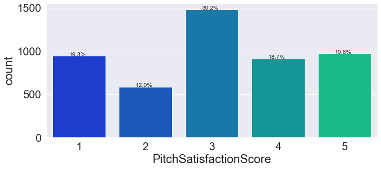

```python
plt.figure(figsize=(12, 5))
perc_on_bar(data["PitchSatisfactionScore"])
```

- Most salespersons scored 3 for their sales-pitch satisfaction score

#### Observations on NumberOfChildrenVisiting:

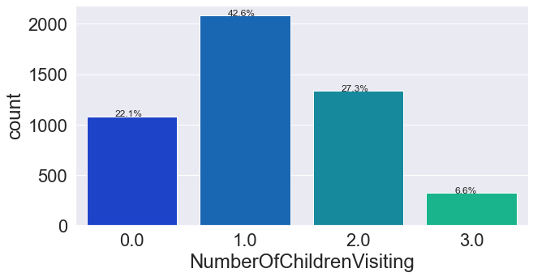

```python
plt.figure(figsize=(10, 5))
perc_on_bar(data["NumberOfChildrenVisiting"])
```

- Most commonly a customer has a child with age less than 5 planning to take the trip with them.

## 3.2) Bivariate Analysis

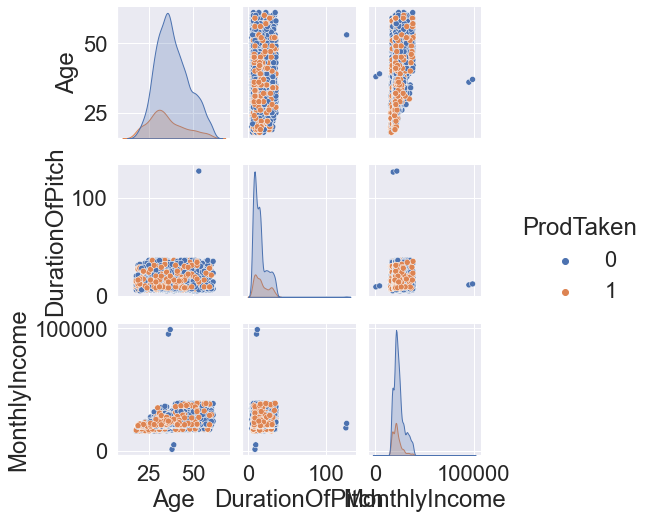

```python
# Let's check the linear relationships of continuous variables
con_paired_cols = ['Age','DurationOfPitch','MonthlyIncome', 'ProdTaken']
sns.pairplot(data[con_paired_cols], hue='ProdTaken')
plt.show()
```

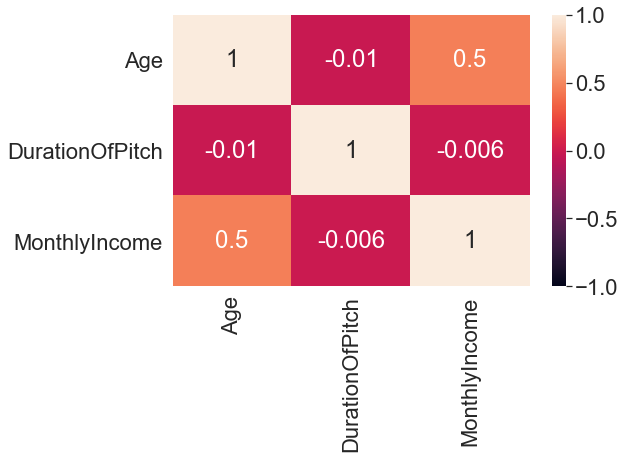

```python
plt.figure(figsize=(8,5))
sns.heatmap(data[con_paired_cols].corr(),annot=True,vmin=-1,vmax=1,fmt='.1g')
plt.show()
```

#### ProdTaken vs Age for different packages:

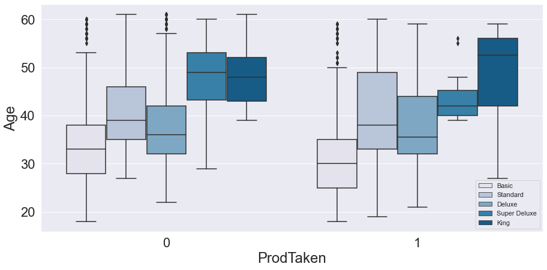

```python
plt.figure(figsize=(15,7))
sns.boxplot(data=data,x='ProdTaken', y='Age',hue='ProductPitched', palette="PuBu")
plt.legend(loc="lower right",  prop={"size":11})
plt.show()
```

- Customers who purchased King Package are from oldest age group (mainly above 50 years old), followed by Super Deluxe (mainly between 40 to 45 years old.
- Customers who purchased Basice Package are among the youngest, ranging from 25 to 35 years old.

#### ProdTaken vs DurationOfPitch for different packages:

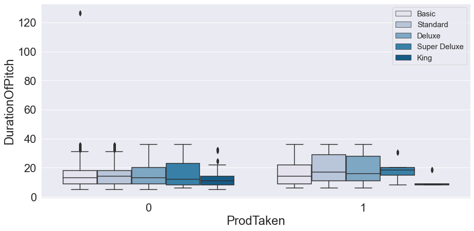

```python
plt.figure(figsize=(15,7))
sns.boxplot(data=data,x='ProdTaken', y='DurationOfPitch',hue='ProductPitched', palette="PuBu")
plt.legend(loc="upper right",  prop={"size":15})
plt.show()
```

- There was an outlier within the group of customers who didn't purchase any travel package, that a salesperson spent 127 units of time on pitching to that customer.
- Excluding the above-mentioned outlier, the duration of the pitch by a salesperson to any customer is strictly less than 40 minutes of time regardless of whether the customer would purchase a travel package or not.
- Surprisingly, salespersons spent very little time pitching to customers who actually purchased King Package.
- Generally, salespersons spent 10 to 25 units of time pitched to customers who eventually purchased either Basic, Standard, or Deluxe package.

#### ProdTaken vs MonthlyIncome for different packages:

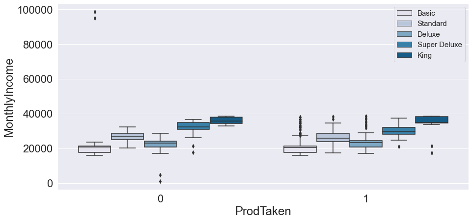

```python
plt.figure(figsize=(15,7))
sns.boxplot(data=data,x='ProdTaken',y='MonthlyIncome',hue='ProductPitched', palette="PuBu")
plt.legend(loc="upper right",  prop={"size":15})
plt.show()
```

- Notice that those who purchased King Package earned the highest MonthlyIncome, followed by those who purchased Super Deluxe Package, and then Standard, Deluxe, and lastly Basic.
- Interestingly, customers who purchased Standard package actually earn higher MonthlyIncome than those who purchased Deluxe package.

### For bivariate analysis on categorical variables, let's study them based on whether a customer purchased any package first, then only we take a closer look into different packages:

```python
## Function to plot stacked bar chart
def stacked_plot(x):
    sns.set(palette="nipy_spectral")
    tab1 = pd.crosstab(x, data["ProdTaken"], margins=True)
    print(tab1)
    print("-" * 110)
    tab = pd.crosstab(x, data["ProdTaken"], normalize="index")
    tab.plot(kind="bar", stacked=True, figsize=(10, 5))
    plt.legend(bbox_to_anchor=(1.00, 1))
    plt.show()
```

#### ProdTaken vs TypeofContact:

```
ProdTaken           0    1   All
TypeofContact
Company Invited  1109  310  1419
Self Enquiry     2837  607  3444
All              3946  917  4863
--------------------------------------------------------------------------------------------------------------
```

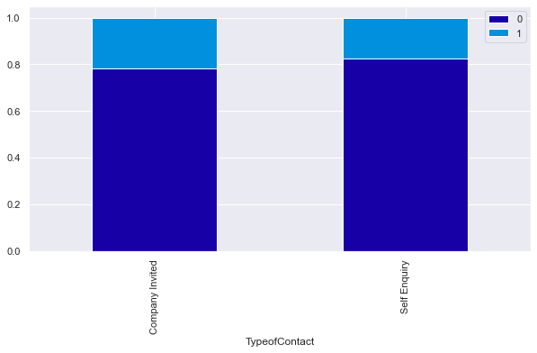

```python
stacked_plot(data["TypeofContact"])
```

- Approx 17.6% of customer contacted by self-enquiry ended up purchase a travel package; while approx 21.8% of customer contacted by invitation company purchased a travel package.

#### ProdTaken vs CityTier:

```
ProdTaken     0    1   All
CityTier
Tier 3     1146  354  1500
Tier 2      152   46   198
Tier 1     2670  520  3190
All        3968  920  4888
--------------------------------------------------------------------------------------------------------------
```

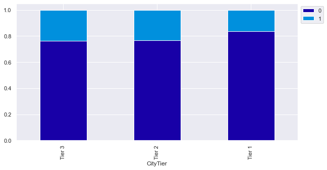

```python
stacked_plot(data["CityTier"])
```

- About 65.3%% of customers are from Tier-1 city, and approx 16.3% of whom purchased a travel package.
- In contrast, approx 30.6% of customers are from Tier-3 city, and approx 23.6% of whom purchased a package.
- There are only appox 4% of customers are from Tier-2 city, and about 23.2% of this 4% customers purchased a package.
- We can see that the company generate **most sales from Tier-1 and Tier-3 cities, but the closure rate is signifiantly higher at Tier-3 city than Tier-1 city.**

#### ProdTaken vs Occupation:

```
ProdTaken          0    1   All
Occupation
Large Business   314  120   434
Salaried        1954  414  2368
Small Business  1700  386  2086
All             3968  920  4888
--------------------------------------------------------------------------------------------------------------
```

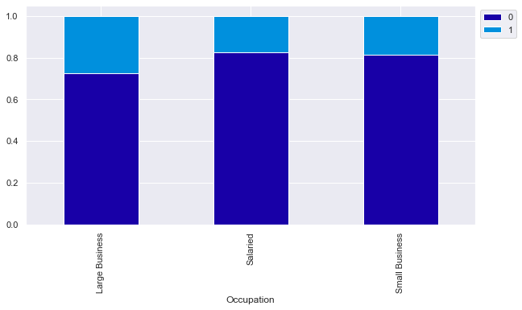

```python
stacked_plot(data["Occupation"])
```

- Approx 17.5% of Salaried customers purchased a travel package, compared with approx 18.5% of small-business customers purchased a package;
- Only about 8.88% of customers are from large business category, but approx 27.6% of this smallest group purchased a package.

#### ProdTaken vs Gender:

```
ProdTaken     0    1   All
Gender
Female     1630  342  1972
Male       2338  578  2916
All        3968  920  4888
--------------------------------------------------------------------------------------------------------------
```

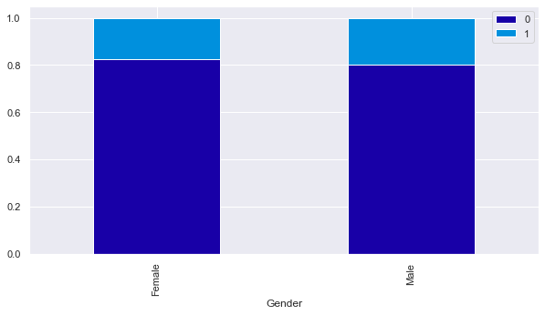

```python
stacked_plot(data["Gender"])
```

- Approx 19.8% of male customers purchased a package, compared with approx 17.3% of female customers purchased a package.

#### ProdTaken vs MaritalStatus:

```
ProdTaken         0    1   All
MaritalStatus
Divorced        826  124   950
Married        2014  326  2340
Single          612  304   916
Unmarried       516  166   682
All            3968  920  4888
--------------------------------------------------------------------------------------------------------------
```

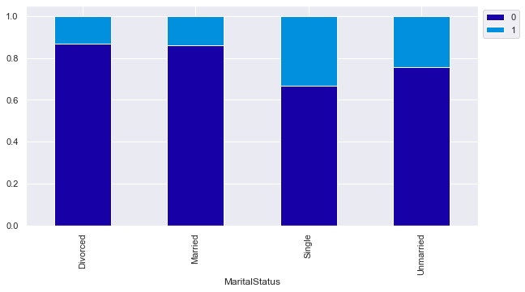

```python
stacked_plot(data["MaritalStatus"])
```

- 33.2% of customers who are single purchased a travel package, the largest percentage as compared with other marital status.
- There was **only approx 13.9%** of married customers purchased a package, yet **nearly half** of the dataset are married customers. This implies that the salespersons have been targeting the wrong group of customers to contact.

#### ProdTaken vs Passport:

```
ProdTaken     0    1   All
Passport
0          3040  426  3466
1           928  494  1422
All        3968  920  4888
--------------------------------------------------------------------------------------------------------------
```

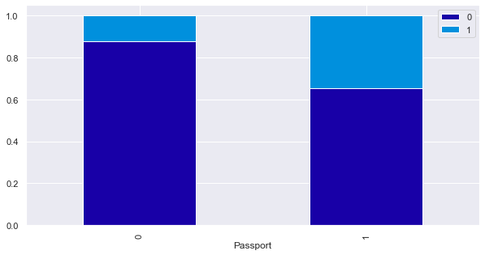

```python
stacked_plot(data["Passport"])
```

- Approx **34.7%** of customers who **has a passport purchased** a travel package, compared with 12.3% of those who doesn't have a passport purchased a package.

#### ProdTaken vs OwnCar:

```
ProdTaken     0    1   All
OwnCar
0          1496  360  1856
1          2472  560  3032
All        3968  920  4888
--------------------------------------------------------------------------------------------------------------
```

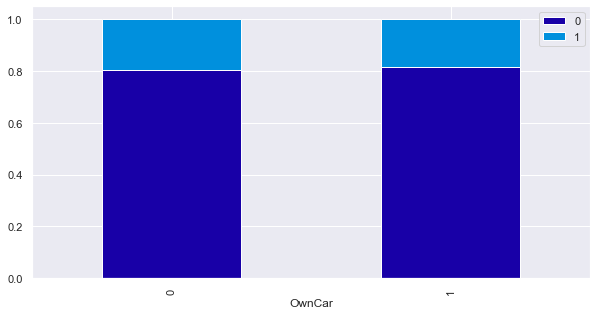

```python
stacked_plot(data["OwnCar"])
```

- There are about the same proportion of customers who purchased or didn't purchase a travel package own a car.